# Question 1

#### A customer informed their consultant that they have developed several formulations of petrol that gives different characteristics of burning pattern. The formulations are obtaining by adding varying levels of additives that, for example, prevent engine knocking, gum prevention, stability in storage, and etc. However, a third party certification organisation would like to verify if the formulations are significantly different, and request for both physical and statistical proof. Since the formulations are confidential information, they are not named in the dataset. Please assist the consultant in the area of statistical analysis by doing this;

a. A descriptive analysis of the additives (columns named as “a” to “i”), which must include summaries of findings (parametric/non-parametric). Correlation and ANOVA, if applicable, is a must.

b. A graphical analysis of the additives, including a distribution study.

c. A clustering test of your choice (unsupervised learning), to determine the distinctive number of formulations present in the dataset.

```python
# Import Packages
import numpy as np
import pandas as pd
import matplotlib.pyplot as plt
import seaborn as sns
sns.set(context="notebook", palette="Spectral", style = 'darkgrid' ,font_scale = 1.5, color_codes=True)
```

```python
df = pd.read_csv('ingredient.csv')
```

```python
#Summary of Ingredient DataFrame
df.info()
```

```
<class 'pandas.core.frame.DataFrame'>
RangeIndex: 214 entries, 0 to 213
Data columns (total 9 columns):
a    214 non-null float64
b    214 non-null float64
c    214 non-null float64
d    214 non-null float64
e    214 non-null float64
f    214 non-null float64
g    214 non-null float64
h    214 non-null float64
i    214 non-null float64
dtypes: float64(9)
memory usage: 15.1 KB
```

##### Ingredients Data have:

```
i. 9 variables
ii. 214 entries
iii. No missing value
iv. All data are in float type
```

```python
#Peeking at dataset
df.head()
```

|  | a | b | c | d | e | f | g | h | i |
| --- | --- | --- | --- | --- | --- | --- | --- | --- | --- |
| 0 | 1.51735 | 13.02 | 3.54 | 1.69 | 72.73 | 0.54 | 8.44 | 0.00 | 0.07 |
| 1 | 1.53125 | 10.73 | 0.00 | 2.10 | 69.81 | 0.58 | 13.30 | 3.15 | 0.28 |
| 2 | 1.52300 | 13.31 | 3.58 | 0.82 | 71.99 | 0.12 | 10.17 | 0.00 | 0.03 |
| 3 | 1.51768 | 12.56 | 3.52 | 1.43 | 73.15 | 0.57 | 8.54 | 0.00 | 0.00 |
| 4 | 1.51813 | 13.43 | 3.98 | 1.18 | 72.49 | 0.58 | 8.15 | 0.00 | 0.00 |

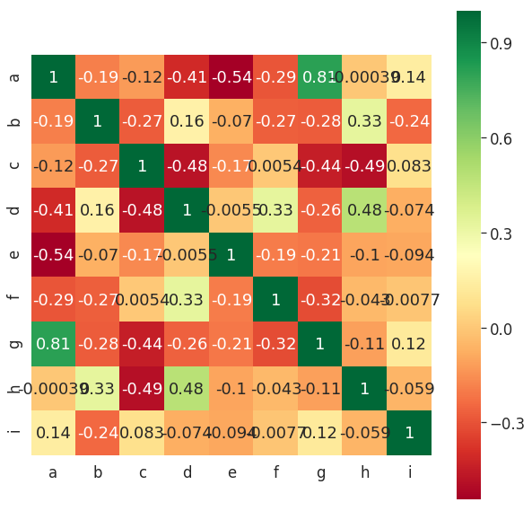

```python
# Find correlation between the additives variables using seaborn heatmap to scan trough
plt.figure(figsize=(10,10))
p=sns.heatmap(df.corr(), annot=True,cmap='RdYlGn',square=True)
```

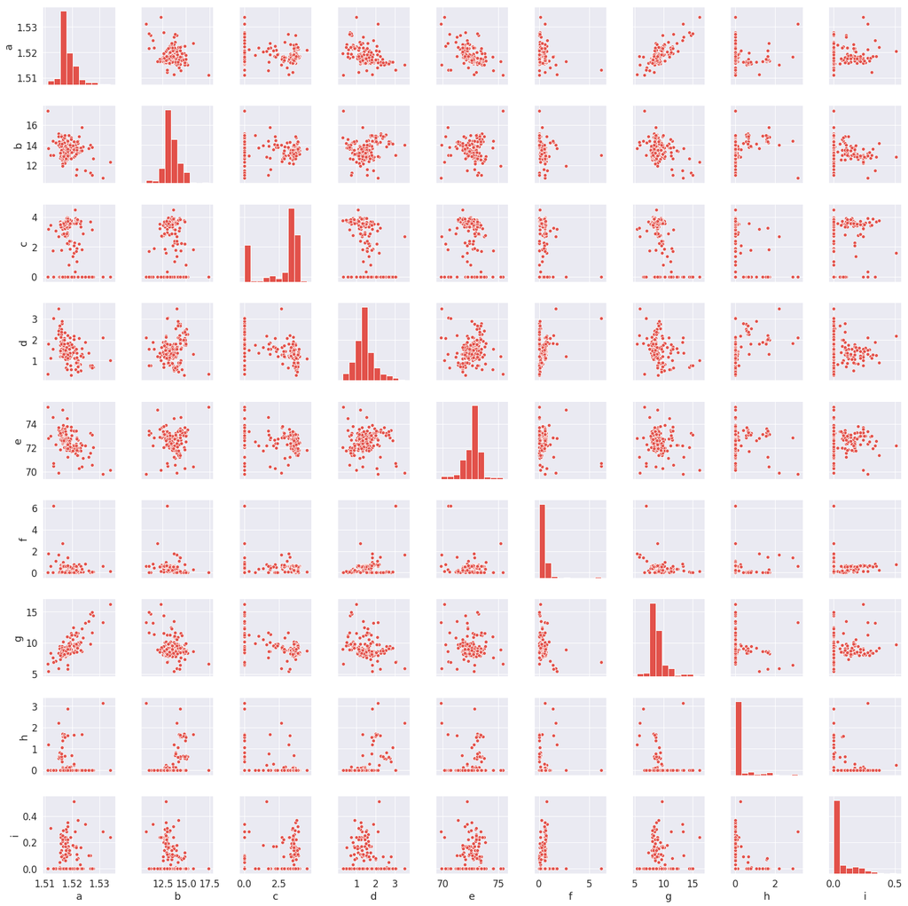

```python
#Plot All graphs to scan trough
p=sns.pairplot(df)
```

#### Observation from the plot

```python
df1 = df.drop(['c','e','i'], axis=1)
```

```python
df1.head()
```

|  | a | b | d | f | g | h |
| --- | --- | --- | --- | --- | --- | --- |
| 0 | 1.51735 | 13.02 | 1.69 | 0.54 | 8.44 | 0.00 |
| 1 | 1.53125 | 10.73 | 2.10 | 0.58 | 13.30 | 3.15 |
| 2 | 1.52300 | 13.31 | 0.82 | 0.12 | 10.17 | 0.00 |
| 3 | 1.51768 | 12.56 | 1.43 | 0.57 | 8.54 | 0.00 |
| 4 | 1.51813 | 13.43 | 1.18 | 0.58 | 8.15 | 0.00 |

### A vs G

[output not shown]

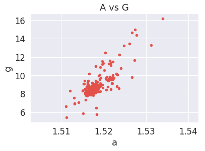

```python
# See closer look on A and G
df.plot(kind="scatter", x="a", y="g")
plt.title('A vs G')
```

D vs B and H vs B

[output not shown]

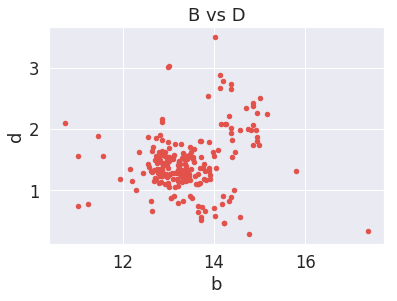

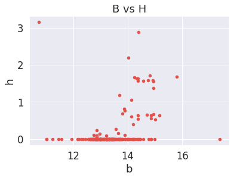

```python
df.plot(kind="scatter", x="b", y="d")
plt.title('B vs D')

df.plot(kind="scatter", x="b", y="h")
plt.title('B vs H')
```

F vs D and H vs D

[output not shown]

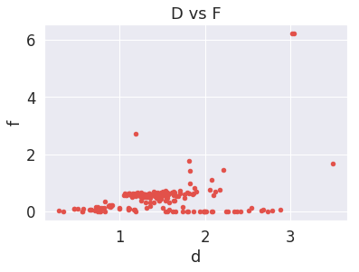

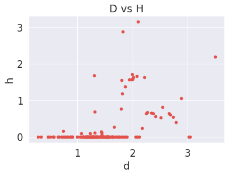

```python
df.plot(kind="scatter", x="d", y="f")
plt.title('D vs F')

df.plot(kind="scatter", x="d", y="h")
plt.title('D vs H')
```

```python
#Distribution study
df1.describe()
```

|  | a | b | d | f | g | h |
| --- | --- | --- | --- | --- | --- | --- |
| count | 214.000000 | 214.000000 | 214.000000 | 214.000000 | 214.000000 | 214.000000 |
| mean | 1.518365 | 13.407850 | 1.444907 | 0.497056 | 8.956963 | 0.175047 |
| std | 0.003037 | 0.816604 | 0.499270 | 0.652192 | 1.423153 | 0.497219 |
| min | 1.511150 | 10.730000 | 0.290000 | 0.000000 | 5.430000 | 0.000000 |
| 25% | 1.516523 | 12.907500 | 1.190000 | 0.122500 | 8.240000 | 0.000000 |
| 50% | 1.517680 | 13.300000 | 1.360000 | 0.555000 | 8.600000 | 0.000000 |
| 75% | 1.519157 | 13.825000 | 1.630000 | 0.610000 | 9.172500 | 0.000000 |
| max | 1.533930 | 17.380000 | 3.500000 | 6.210000 | 16.190000 | 3.150000 |

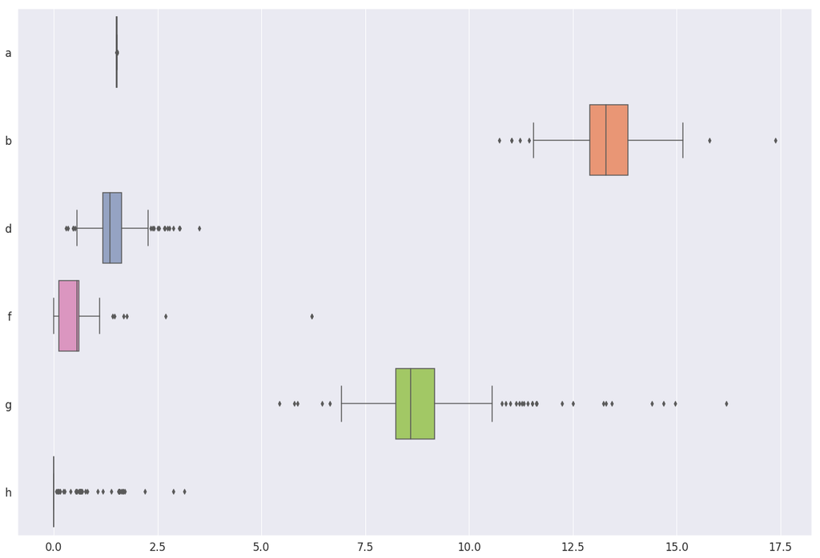

```python
plt.figure(figsize=(22,15))
sns.boxplot(data=df1, orient="h", palette="Set2")
```

```
array([[<matplotlib.axes._subplots.AxesSubplot object at 0x7ff3838c4f28>,
      dtype=object)
```

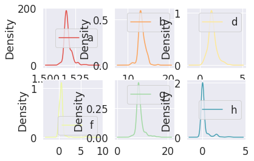

```python
df1.plot(kind='density', subplots=True, layout=(2,3), sharex=False, sharey=False)
```

All features are positive skew

```python
#Import packages to conduct unsupervised machine learning
from sklearn.cluster import KMeans
from sklearn.metrics import accuracy_score
from sklearn.preprocessing import StandardScaler
```

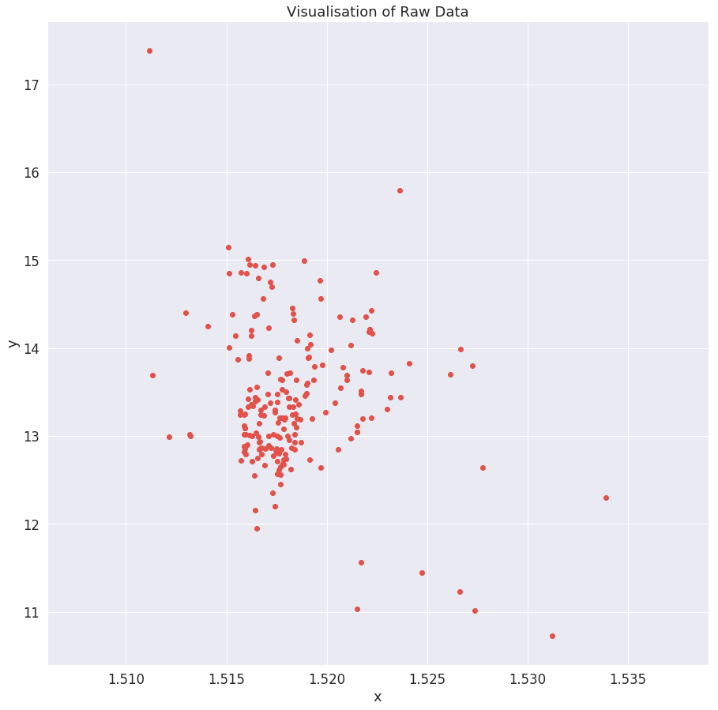

```python
plt.figure(figsize=(15, 15))
plt.scatter(df1.iloc[:, 0], df1.iloc[:, 1])
plt.xlabel('x')
plt.ylabel('y')
plt.title('Visualisation of Raw Data');
```

```python
#Convert data to numpy array for faster computation
X = df1.values
X
```

```
array([[ 1.51735, 13.02   ,  1.69   ,  0.54   ,  8.44   ,  0.     ],
       [ 1.53125, 10.73   ,  2.1    ,  0.58   , 13.3    ,  3.15   ],
       [ 1.523  , 13.31   ,  0.82   ,  0.12   , 10.17   ,  0.     ],
       ...,
       [ 1.51784, 12.68   ,  1.16   ,  0.61   ,  8.7    ,  0.     ],
       [ 1.51841, 12.93   ,  1.11   ,  0.64   ,  8.96   ,  0.     ],
       [ 1.51321, 13.     ,  3.02   ,  6.21   ,  6.93   ,  0.     ]])
```

```python
# Standardize the data
X_std = StandardScaler().fit_transform(X)
```

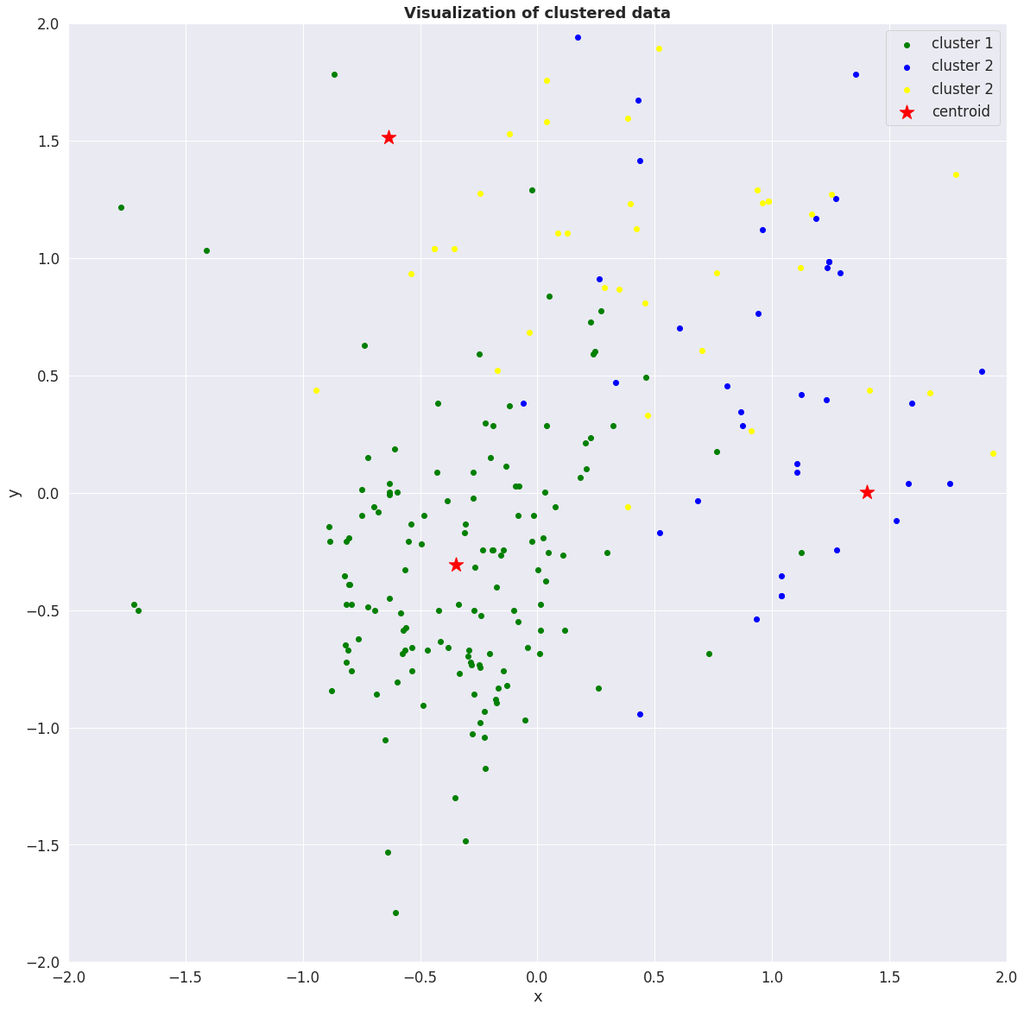

```python
# Fitting K-Means to the dataset
km = KMeans(n_clusters=3, max_iter=300)
km.fit(X_std)
labels = km.labels_
centroids = km.cluster_centers_

# Plot the clustered data
fig, ax = plt.subplots(figsize=(20, 20))
plt.scatter(X_std[labels == 0, 0], X_std[labels == 0, 1],
            c='green', label='cluster 1')
plt.scatter(X_std[labels == 1, 0], X_std[labels == 1, 1],
            c='blue', label='cluster 2')
plt.scatter(X_std[labels == 1, 1], X_std[labels == 1, 0],
            c='yellow', label='cluster 2')
plt.scatter(centroids[:, 0], centroids[:, 1], marker='*', s=300,
            c='r', label='centroid')
plt.legend()
plt.xlim([-2, 2])
plt.ylim([-2, 2])
plt.xlabel('x')
plt.ylabel('y')
plt.title('Visualization of clustered data', fontweight='bold')
ax.set_aspect('equal');
```